# Traditional Exploration

```python
import pandas as pd
import numpy as np
%matplotlib inline
import matplotlib.pyplot as plt
import matplotlib as mpl
import seaborn as sns
sns.set()
```

```python
hourly_bike_data = pd.read_csv('hour.csv');
daily_bike_data = pd.read_csv('day.csv');
```

```python
hourly_bike_data.head()
```

|  | instant | dteday | season | yr | mnth | hr | holiday | weekday | workingday | weathersit | temp | atemp | hum | windspeed | casual | registered | cnt |
| --- | --- | --- | --- | --- | --- | --- | --- | --- | --- | --- | --- | --- | --- | --- | --- | --- | --- |
| 0 | 1 | 2011-01-01 | 1 | 0 | 1 | 0 | 0 | 6 | 0 | 1 | 0.24 | 0.2879 | 0.81 | 0.0 | 3 | 13 | 16 |
| 1 | 2 | 2011-01-01 | 1 | 0 | 1 | 1 | 0 | 6 | 0 | 1 | 0.22 | 0.2727 | 0.80 | 0.0 | 8 | 32 | 40 |
| 2 | 3 | 2011-01-01 | 1 | 0 | 1 | 2 | 0 | 6 | 0 | 1 | 0.22 | 0.2727 | 0.80 | 0.0 | 5 | 27 | 32 |
| 3 | 4 | 2011-01-01 | 1 | 0 | 1 | 3 | 0 | 6 | 0 | 1 | 0.24 | 0.2879 | 0.75 | 0.0 | 3 | 10 | 13 |
| 4 | 5 | 2011-01-01 | 1 | 0 | 1 | 4 | 0 | 6 | 0 | 1 | 0.24 | 0.2879 | 0.75 | 0.0 | 0 | 1 | 1 |

```python
daily_bike_data.head()
```

|  | instant | dteday | season | yr | mnth | holiday | weekday | workingday | weathersit | temp | atemp | hum | windspeed | casual | registered | cnt |
| --- | --- | --- | --- | --- | --- | --- | --- | --- | --- | --- | --- | --- | --- | --- | --- | --- |
| 0 | 1 | 2011-01-01 | 1 | 0 | 1 | 0 | 6 | 0 | 2 | 0.344167 | 0.363625 | 0.805833 | 0.160446 | 331 | 654 | 985 |
| 1 | 2 | 2011-01-02 | 1 | 0 | 1 | 0 | 0 | 0 | 2 | 0.363478 | 0.353739 | 0.696087 | 0.248539 | 131 | 670 | 801 |
| 2 | 3 | 2011-01-03 | 1 | 0 | 1 | 0 | 1 | 1 | 1 | 0.196364 | 0.189405 | 0.437273 | 0.248309 | 120 | 1229 | 1349 |
| 3 | 4 | 2011-01-04 | 1 | 0 | 1 | 0 | 2 | 1 | 1 | 0.200000 | 0.212122 | 0.590435 | 0.160296 | 108 | 1454 | 1562 |
| 4 | 5 | 2011-01-05 | 1 | 0 | 1 | 0 | 3 | 1 | 1 | 0.226957 | 0.229270 | 0.436957 | 0.186900 | 82 | 1518 | 1600 |

```python
daily_bike_data.info()
```

```
<class 'pandas.core.frame.DataFrame'>
RangeIndex: 731 entries, 0 to 730
Data columns (total 16 columns):
instant       731 non-null int64
dteday        731 non-null object
season        731 non-null int64
yr            731 non-null int64
mnth          731 non-null int64
holiday       731 non-null int64
weekday       731 non-null int64
workingday    731 non-null int64
weathersit    731 non-null int64
temp          731 non-null float64
atemp         731 non-null float64
hum           731 non-null float64
windspeed     731 non-null float64
casual        731 non-null int64
registered    731 non-null int64
cnt           731 non-null int64
dtypes: float64(4), int64(11), object(1)
memory usage: 91.5+ KB
```

```python
hourly_bike_data.info()
```

```
<class 'pandas.core.frame.DataFrame'>
RangeIndex: 17379 entries, 0 to 17378
Data columns (total 17 columns):
instant       17379 non-null int64
dteday        17379 non-null object
season        17379 non-null int64
yr            17379 non-null int64
mnth          17379 non-null int64
hr            17379 non-null int64
holiday       17379 non-null int64
weekday       17379 non-null int64
workingday    17379 non-null int64
weathersit    17379 non-null int64
temp          17379 non-null float64
atemp         17379 non-null float64
hum           17379 non-null float64
windspeed     17379 non-null float64
casual        17379 non-null int64
registered    17379 non-null int64
cnt           17379 non-null int64
dtypes: float64(4), int64(12), object(1)
memory usage: 2.3+ MB
```

```python
hourly_bike_data.describe()
```

|  | instant | season | yr | mnth | hr | holiday | weekday | workingday | weathersit | temp | atemp | hum | windspeed | casual | registered | cnt |
| --- | --- | --- | --- | --- | --- | --- | --- | --- | --- | --- | --- | --- | --- | --- | --- | --- |
| count | 17379.0000 | 17379.000000 | 17379.000000 | 17379.000000 | 17379.000000 | 17379.000000 | 17379.000000 | 17379.000000 | 17379.000000 | 17379.000000 | 17379.000000 | 17379.000000 | 17379.000000 | 17379.000000 | 17379.000000 | 17379.000000 |
| mean | 8690.0000 | 2.501640 | 0.502561 | 6.537775 | 11.546752 | 0.028770 | 3.003683 | 0.682721 | 1.425283 | 0.496987 | 0.475775 | 0.627229 | 0.190098 | 35.676218 | 153.786869 | 189.463088 |
| std | 5017.0295 | 1.106918 | 0.500008 | 3.438776 | 6.914405 | 0.167165 | 2.005771 | 0.465431 | 0.639357 | 0.192556 | 0.171850 | 0.192930 | 0.122340 | 49.305030 | 151.357286 | 181.387599 |
| min | 1.0000 | 1.000000 | 0.000000 | 1.000000 | 0.000000 | 0.000000 | 0.000000 | 0.000000 | 1.000000 | 0.020000 | 0.000000 | 0.000000 | 0.000000 | 0.000000 | 0.000000 | 1.000000 |
| 25% | 4345.5000 | 2.000000 | 0.000000 | 4.000000 | 6.000000 | 0.000000 | 1.000000 | 0.000000 | 1.000000 | 0.340000 | 0.333300 | 0.480000 | 0.104500 | 4.000000 | 34.000000 | 40.000000 |
| 50% | 8690.0000 | 3.000000 | 1.000000 | 7.000000 | 12.000000 | 0.000000 | 3.000000 | 1.000000 | 1.000000 | 0.500000 | 0.484800 | 0.630000 | 0.194000 | 17.000000 | 115.000000 | 142.000000 |
| 75% | 13034.5000 | 3.000000 | 1.000000 | 10.000000 | 18.000000 | 0.000000 | 5.000000 | 1.000000 | 2.000000 | 0.660000 | 0.621200 | 0.780000 | 0.253700 | 48.000000 | 220.000000 | 281.000000 |
| max | 17379.0000 | 4.000000 | 1.000000 | 12.000000 | 23.000000 | 1.000000 | 6.000000 | 1.000000 | 4.000000 | 1.000000 | 1.000000 | 1.000000 | 0.850700 | 367.000000 | 886.000000 | 977.000000 |

```python
daily_index = pd.DatetimeIndex(daily_bike_data['dteday'])
daily_bike_data.index = daily_index
daily_bike_data.head()
```

| dteday | instant | dteday | season | yr | mnth | holiday | weekday | workingday | weathersit | temp | atemp | hum | windspeed | casual | registered | cnt |
| --- | --- | --- | --- | --- | --- | --- | --- | --- | --- | --- | --- | --- | --- | --- | --- | --- |
| 2011-01-01 | 1 | 2011-01-01 | 1 | 0 | 1 | 0 | 6 | 0 | 2 | 0.344167 | 0.363625 | 0.805833 | 0.160446 | 331 | 654 | 985 |
| 2011-01-02 | 2 | 2011-01-02 | 1 | 0 | 1 | 0 | 0 | 0 | 2 | 0.363478 | 0.353739 | 0.696087 | 0.248539 | 131 | 670 | 801 |
| 2011-01-03 | 3 | 2011-01-03 | 1 | 0 | 1 | 0 | 1 | 1 | 1 | 0.196364 | 0.189405 | 0.437273 | 0.248309 | 120 | 1229 | 1349 |
| 2011-01-04 | 4 | 2011-01-04 | 1 | 0 | 1 | 0 | 2 | 1 | 1 | 0.200000 | 0.212122 | 0.590435 | 0.160296 | 108 | 1454 | 1562 |
| 2011-01-05 | 5 | 2011-01-05 | 1 | 0 | 1 | 0 | 3 | 1 | 1 | 0.226957 | 0.229270 | 0.436957 | 0.186900 | 82 | 1518 | 1600 |

```python
hourly_index = hourly_bike_data['dteday'] + ' ' + hourly_bike_data['hr'].apply(lambda x: '%02d' % x).apply(str)
hourly_index.head()
```

```
0    2011-01-01 00
1    2011-01-01 01
2    2011-01-01 02
3    2011-01-01 03
4    2011-01-01 04
dtype: object
```

```python
hourly_index = pd.to_datetime(hourly_index, format="%Y-%m-%d %H")
hourly_index.head()
```

```
0   2011-01-01 00:00:00
1   2011-01-01 01:00:00
2   2011-01-01 02:00:00
3   2011-01-01 03:00:00
4   2011-01-01 04:00:00
dtype: datetime64[ns]
```

```python
hourly_bike_data.index = hourly_index
hourly_bike_data.head()
```

|  | instant | dteday | season | yr | mnth | hr | holiday | weekday | workingday | weathersit | temp | atemp | hum | windspeed | casual | registered | cnt |
| --- | --- | --- | --- | --- | --- | --- | --- | --- | --- | --- | --- | --- | --- | --- | --- | --- | --- |
| 2011-01-01 00:00:00 | 1 | 2011-01-01 | 1 | 0 | 1 | 0 | 0 | 6 | 0 | 1 | 0.24 | 0.2879 | 0.81 | 0.0 | 3 | 13 | 16 |
| 2011-01-01 01:00:00 | 2 | 2011-01-01 | 1 | 0 | 1 | 1 | 0 | 6 | 0 | 1 | 0.22 | 0.2727 | 0.80 | 0.0 | 8 | 32 | 40 |
| 2011-01-01 02:00:00 | 3 | 2011-01-01 | 1 | 0 | 1 | 2 | 0 | 6 | 0 | 1 | 0.22 | 0.2727 | 0.80 | 0.0 | 5 | 27 | 32 |
| 2011-01-01 03:00:00 | 4 | 2011-01-01 | 1 | 0 | 1 | 3 | 0 | 6 | 0 | 1 | 0.24 | 0.2879 | 0.75 | 0.0 | 3 | 10 | 13 |
| 2011-01-01 04:00:00 | 5 | 2011-01-01 | 1 | 0 | 1 | 4 | 0 | 6 | 0 | 1 | 0.24 | 0.2879 | 0.75 | 0.0 | 0 | 1 | 1 |

```python
hourly_bike_data.drop(labels=['instant', 'dteday', 'yr', 'mnth', 'hr'], inplace=True, axis=1)
hourly_bike_data.head(3)
```

|  | season | holiday | weekday | workingday | weathersit | temp | atemp | hum | windspeed | casual | registered | cnt |
| --- | --- | --- | --- | --- | --- | --- | --- | --- | --- | --- | --- | --- |
| 2011-01-01 00:00:00 | 1 | 0 | 6 | 0 | 1 | 0.24 | 0.2879 | 0.81 | 0.0 | 3 | 13 | 16 |
| 2011-01-01 01:00:00 | 1 | 0 | 6 | 0 | 1 | 0.22 | 0.2727 | 0.80 | 0.0 | 8 | 32 | 40 |
| 2011-01-01 02:00:00 | 1 | 0 | 6 | 0 | 1 | 0.22 | 0.2727 | 0.80 | 0.0 | 5 | 27 | 32 |

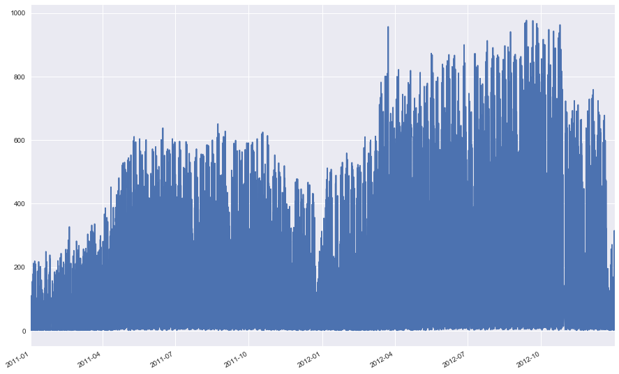

```python
fig = plt.figure(figsize=(15,10))
hourly_bike_data['cnt'].plot()
```

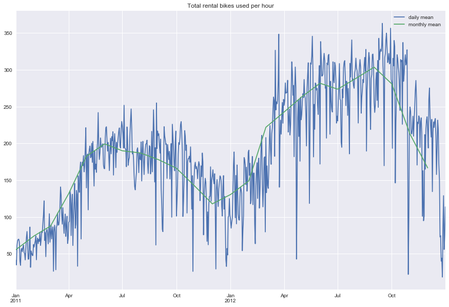

```python
fig = plt.figure(figsize=(15,10))
hourly_bike_data.resample('D').mean()['cnt'].plot()
hourly_bike_data.resample('M').mean()['cnt'].plot()
plt.legend(['daily mean', 'monthly mean'])
plt.title('Total rental bikes used per hour')
```

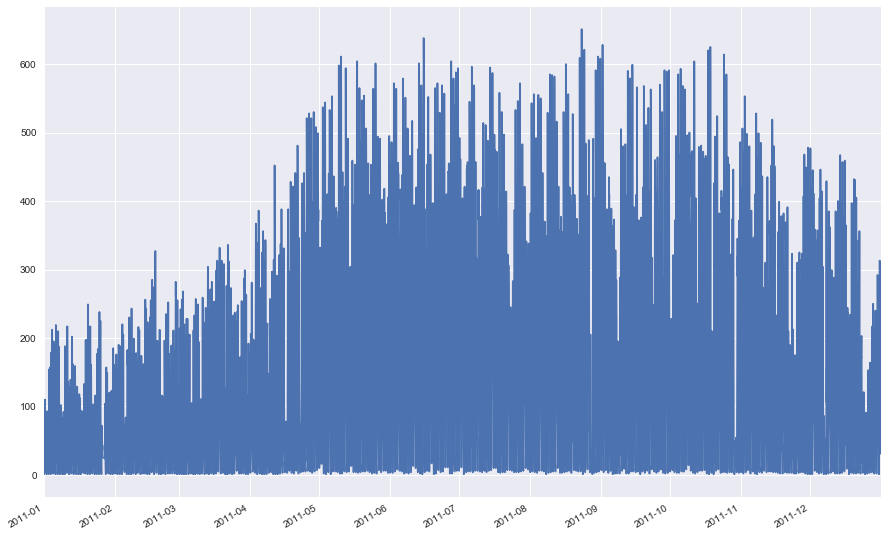

```python
fig = plt.figure(figsize=(15,10))
hourly_bike_data['2011']['cnt'].plot()
```

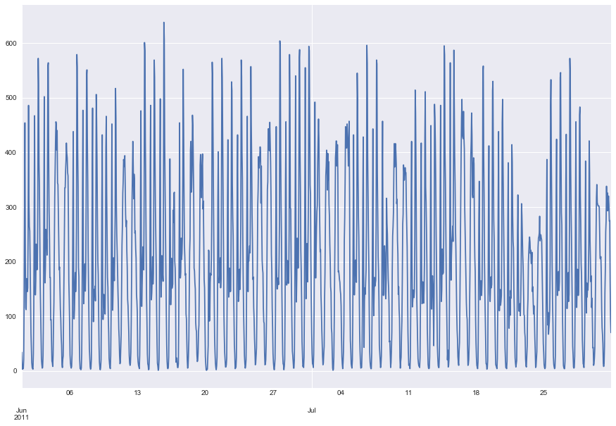

```python
fig = plt.figure(figsize=(15,10))
hourly_bike_data['2011-06' : '2011-7']['cnt'].plot()
```

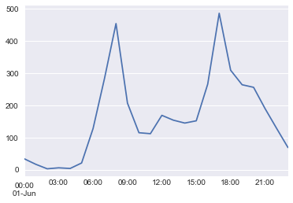

```python
hourly_bike_data['2011-06-1']['cnt'].plot()
```

```python
from dateutil import parser
parser.parse('2011-06-06').weekday()
```

```
0
```

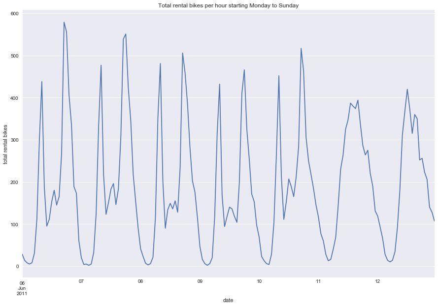

```python
fig = plt.figure(figsize=(15,10))
ax = plt.axes()

hourly_bike_data['2011-06-6':'2011-06-12']['cnt'].plot()

plt.title('Total rental bikes per hour starting Monday to Sunday')
plt.ylabel('total rental bikes')
plt.xlabel('date')
```

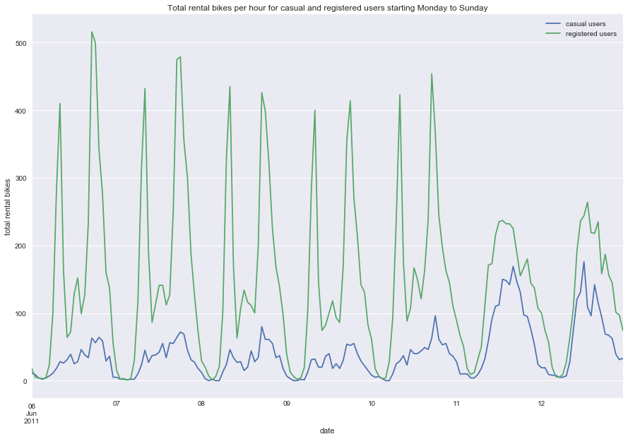

```python
fig = plt.figure(figsize=(15,10))
ax = plt.axes()

hourly_bike_data['2011-06-6':'2011-06-12']['casual'].plot()
hourly_bike_data['2011-06-6':'2011-06-12']['registered'].plot()

plt.legend(['casual users', 'registered users']);
plt.title('Total rental bikes per hour for casual and registered users starting Monday to Sunday')
plt.ylabel('total rental bikes')
plt.xlabel('date')
```

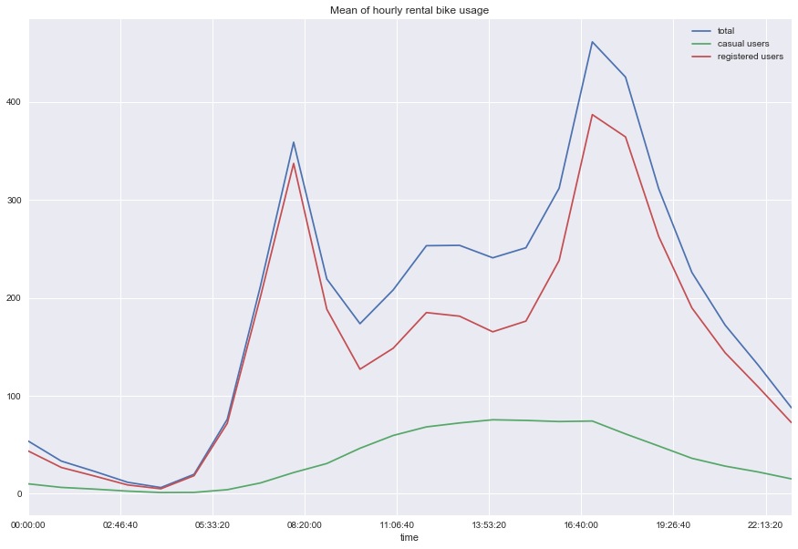

```python
hourly_mean = hourly_bike_data.groupby(hourly_bike_data.index.time).mean()

fig = plt.figure(figsize=(15,10))
ax = plt.axes()

hourly_mean['cnt'].plot()
hourly_mean['casual'].plot()
hourly_mean['registered'].plot()

plt.legend(['total', 'casual users', 'registered users'])
plt.title('Mean of hourly rental bike usage')
```

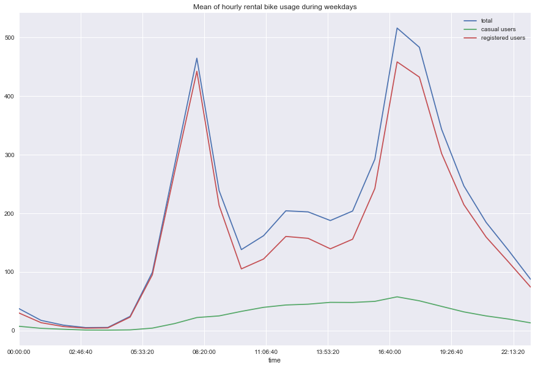

```python
weekdays_hourly_bike_data = hourly_bike_data[hourly_bike_data.index.dayofweek < 5];
weekdays_hourly_mean = weekdays_hourly_bike_data.groupby(weekdays_hourly_bike_data.index.time).mean()

fig = plt.figure(figsize=(15,10))
ax = plt.axes()

weekdays_hourly_mean['cnt'].plot()
weekdays_hourly_mean['casual'].plot()
weekdays_hourly_mean['registered'].plot()

plt.legend(['total', 'casual users', 'registered users'])
plt.title('Mean of hourly rental bike usage during weekdays')
```

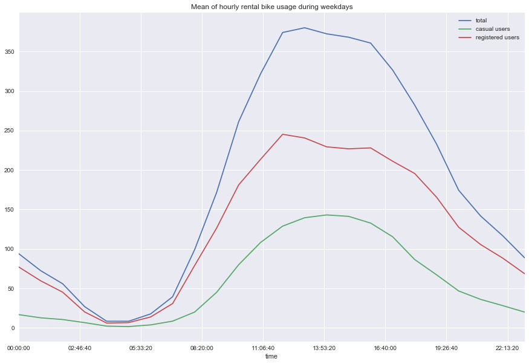

```python
weekends_hourly_bike_data = hourly_bike_data[hourly_bike_data.index.dayofweek > 4];
weekends_hourly_mean = weekends_hourly_bike_data.groupby(weekends_hourly_bike_data.index.time).mean()

fig = plt.figure(figsize=(15,10))
ax = plt.axes()

weekends_hourly_mean['cnt'].plot()
weekends_hourly_mean['casual'].plot()
weekends_hourly_mean['registered'].plot()

plt.legend(['total', 'casual users', 'registered users'])
plt.title('Mean of hourly rental bike usage during weekdays')
```

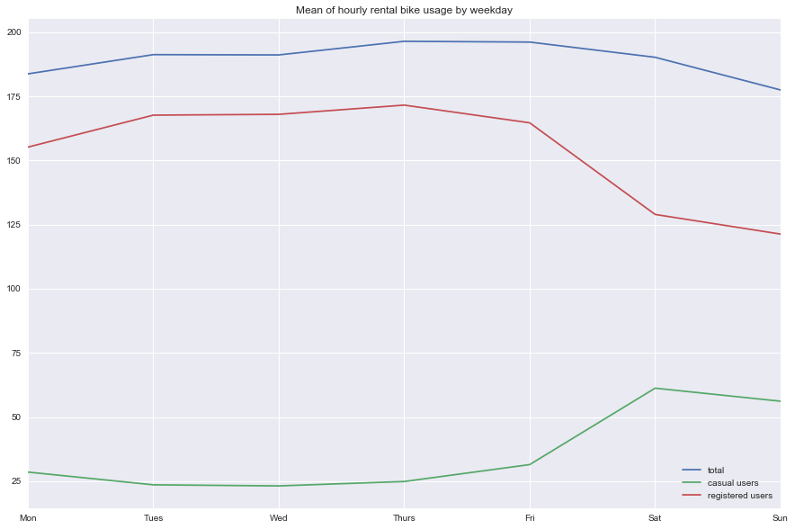

```python
hourly_bike_data_by_weekday = hourly_bike_data.groupby(hourly_bike_data.index.dayofweek).mean()
hourly_bike_data_by_weekday.index = ['Mon', 'Tues', 'Wed', 'Thurs', 'Fri', 'Sat', 'Sun']

fig = plt.figure(figsize=(15,10))
ax = plt.axes()

hourly_bike_data_by_weekday['cnt'].plot();
hourly_bike_data_by_weekday['casual'].plot();
hourly_bike_data_by_weekday['registered'].plot();

plt.legend(['total', 'casual users', 'registered users'])
plt.title('Mean of hourly rental bike usage by weekday')
```

# Preprocessing

Lets load the fresh dataset again. A lot of the data preprocessing seems to have been done already but let's see if we can do some feature engineering

```python
hourly_bike_data = pd.read_csv('hour.csv');
```

Split the data into training and testing data. Using 20% of the data for testing

```python
from sklearn.model_selection import train_test_split
train_set, test_set = train_test_split(hourly_bike_data, test_size=0.2, random_state=711)
```

```python
train_set.info()
```

```
<class 'pandas.core.frame.DataFrame'>
Int64Index: 13903 entries, 9610 to 2657
Data columns (total 17 columns):
instant       13903 non-null int64
dteday        13903 non-null object
season        13903 non-null int64
yr            13903 non-null int64
mnth          13903 non-null int64
hr            13903 non-null int64
holiday       13903 non-null int64
weekday       13903 non-null int64
workingday    13903 non-null int64
weathersit    13903 non-null int64
temp          13903 non-null float64
atemp         13903 non-null float64
hum           13903 non-null float64
windspeed     13903 non-null float64
casual        13903 non-null int64
registered    13903 non-null int64
cnt           13903 non-null int64
dtypes: float64(4), int64(12), object(1)
memory usage: 1.9+ MB
```

```python
train_set.head()
```

|  | instant | dteday | season | yr | mnth | hr | holiday | weekday | workingday | weathersit | temp | atemp | hum | windspeed | casual | registered | cnt |
| --- | --- | --- | --- | --- | --- | --- | --- | --- | --- | --- | --- | --- | --- | --- | --- | --- | --- |
| 9610 | 9611 | 2012-02-10 | 1 | 1 | 2 | 9 | 0 | 5 | 1 | 1 | 0.22 | 0.2273 | 0.55 | 0.1642 | 10 | 265 | 275 |
| 14185 | 14186 | 2012-08-19 | 3 | 1 | 8 | 6 | 0 | 0 | 0 | 2 | 0.62 | 0.6061 | 0.69 | 0.1045 | 5 | 15 | 20 |
| 2305 | 2306 | 2011-04-10 | 2 | 0 | 4 | 22 | 0 | 0 | 0 | 1 | 0.44 | 0.4394 | 0.94 | 0.2537 | 12 | 45 | 57 |
| 10605 | 10606 | 2012-03-23 | 2 | 1 | 3 | 0 | 0 | 5 | 1 | 1 | 0.56 | 0.5303 | 0.83 | 0.0000 | 30 | 65 | 95 |
| 14760 | 14761 | 2012-09-12 | 3 | 1 | 9 | 5 | 0 | 3 | 1 | 1 | 0.50 | 0.4848 | 0.72 | 0.0896 | 4 | 44 | 48 |

By checking linear correlations, we can see that temperature, hour and humidity seem to be the most important fields correlating to the number of bikes used. Temperature and humidity seems to be more important for casual users than registered users, while the hour seems to be correlating more with registered users than casual users

```python
corr_matrix = train_set.corr()
corr_matrix['cnt'].sort_values(ascending=False)
```

```
cnt           1.000000
registered    0.972443
casual        0.693819
temp          0.404812
atemp         0.401073
hr            0.389286
instant       0.279325
yr            0.250339
season        0.181192
mnth          0.123268
windspeed     0.086582
workingday    0.034776
weekday       0.026815
holiday      -0.033183
weathersit   -0.143671
hum          -0.324951
Name: cnt, dtype: float64
```

```python
corr_matrix['registered'].sort_values(ascending=False)
```

```
registered    1.000000
cnt           0.972443
casual        0.506805
hr            0.369511
temp          0.335090
atemp         0.332202
instant       0.283395
yr            0.253694
season        0.178065
workingday    0.137956
mnth          0.125391
windspeed     0.076551
weekday       0.022405
holiday      -0.049860
weathersit   -0.121919
hum          -0.276446
Name: registered, dtype: float64
```

```python
corr_matrix['casual'].sort_values(ascending=False)
```

```
casual        1.000000
cnt           0.693819
registered    0.506805
temp          0.461773
atemp         0.456870
hr            0.298042
instant       0.157453
yr            0.142018
season        0.119952
windspeed     0.083689
mnth          0.068476
holiday       0.031315
weekday       0.029945
weathersit   -0.154640
workingday   -0.297548
hum          -0.347627
Name: casual, dtype: float64
```

We can also plot scatter matrices to try to spot correlations that are not linear.

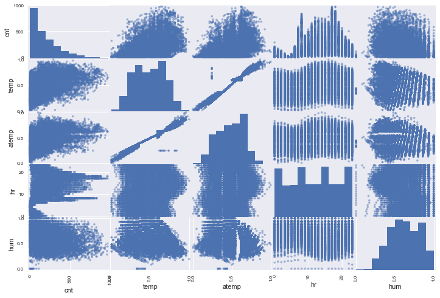

```python
from pandas.plotting import scatter_matrix;
attributes = ['cnt', 'temp', 'atemp', 'hr', 'hum'];
scatter_matrix(train_set[attributes], figsize=(12, 8));
```

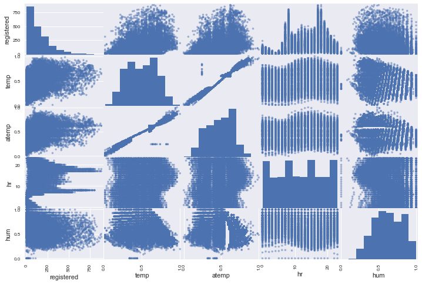

```python
attributes = ['registered', 'temp', 'atemp', 'hr', 'hum'];
scatter_matrix(train_set[attributes], figsize=(12, 8));
```

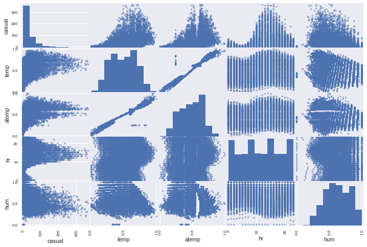

```python
attributes = ['casual', 'temp', 'atemp', 'hr', 'hum'];
scatter_matrix(train_set[attributes], figsize=(12, 8));
```

```python
from sklearn.base import BaseEstimator, TransformerMixin
from sklearn.pipeline import Pipeline
```

```python
class DataFrameSelector(BaseEstimator, TransformerMixin):
    def __init__(self, attribute_names):
        self.attribute_names = attribute_names
    def fit(self, X, y=None):
        return self
    def transform(self, X):
        return X[self.attribute_names].values
```

```python
attribs = ['temp', 'atemp', 'hr', 'yr', 'season', 'windspeed', 'mnth', 'workingday', 'weekday', 'holiday', 'weathersit', 'hum']
full_pipeline = Pipeline([
        ('selector', DataFrameSelector(attribs)),
    ])
```

# Finding a model

```python
X = full_pipeline.fit_transform(train_set)
```

```python
y = train_set['cnt'].values
```

```python
from sklearn.linear_model import LinearRegression
lin_reg = LinearRegression()
lin_reg.fit(X, y)
```

```
LinearRegression(copy_X=True, fit_intercept=True, n_jobs=1, normalize=False)
```

```python
some_data = full_pipeline.transform(hourly_bike_data.iloc[:10])
some_labels = hourly_bike_data['cnt'].iloc[:10].values
print('Predictions: ', lin_reg.predict(some_data))
```

```
Predictions:  [-74.02251564 -69.55328319 -61.97787807 -39.12396548 -31.54856036
 -29.63533161 -31.67625757 -41.38550668  -1.24693987  24.79417198]
```

```python
print('Labels: ', some_labels)
```

```
Labels:  [16 40 32 13  1  1  2  3  8 14]
```

```python
from sklearn.metrics import mean_squared_error
predictions = lin_reg.predict(X)
lin_mse = mean_squared_error(y, predictions)
lin_rmse = np.sqrt(lin_mse)
lin_rmse
```

```
142.08094829675946
```

```python
from sklearn.model_selection import GridSearchCV
from sklearn.ensemble import RandomForestRegressor

param_grid = [
    {'n_estimators': [3, 5, 30], 'max_features': [2, 4, 6, 8]},
    {'bootstrap': [False], 'n_estimators': [3, 10], 'max_features': [2, 3, 4]},
]

forest_reg = RandomForestRegressor()
grid_search = GridSearchCV(forest_reg, param_grid, cv=5, scoring='neg_mean_squared_error')
grid_search.fit(X, y)
```

```
GridSearchCV(cv=5, error_score='raise',
       estimator=RandomForestRegressor(bootstrap=True, criterion='mse', max_depth=None,
           max_features='auto', max_leaf_nodes=None,
           min_impurity_decrease=0.0, min_impurity_split=None,
           min_samples_leaf=1, min_samples_split=2,
           min_weight_fraction_leaf=0.0, n_estimators=10, n_jobs=1,
           oob_score=False, random_state=None, verbose=0, warm_start=False),
       fit_params=None, iid=True, n_jobs=1,
       param_grid=[{'n_estimators': [3, 5, 30], 'max_features': [2, 4, 6, 8]}, {'bootstrap': [False], 'n_estimators': [3, 10], 'max_features': [2, 3, 4]}],
       pre_dispatch='2*n_jobs', refit=True, return_train_score=True,
       scoring='neg_mean_squared_error', verbose=0)
```

```python
grid_search.best_params_
```

```
{'max_features': 8, 'n_estimators': 30}
```

```python
grid_search.best_estimator_
```

```
RandomForestRegressor(bootstrap=True, criterion='mse', max_depth=None,
           max_features=8, max_leaf_nodes=None, min_impurity_decrease=0.0,
           min_impurity_split=None, min_samples_leaf=1,
           min_samples_split=2, min_weight_fraction_leaf=0.0,
           n_estimators=30, n_jobs=1, oob_score=False, random_state=None,
           verbose=0, warm_start=False)
```

As seen below, hour seems to be the most important feature by far

```python
grid_search.best_estimator_.feature_importances_
```

```
array([ 0.0809258 ,  0.07929509,  0.5673831 ,  0.08048179,  0.01996586,
        0.01219513,  0.01980971,  0.05710243,  0.02411923,  0.00214474,
        0.01682358,  0.03975355])
```

```python
train_set[attribs].head(0)
```

|  | temp | atemp | hr | yr | season | windspeed | mnth | workingday | weekday | holiday | weathersit | hum |
| --- | --- | --- | --- | --- | --- | --- | --- | --- | --- | --- | --- | --- |

Final random forest regressor model is below and it has a root mean squared error of around 43 bikes per hour on the test set

```python
final_model = grid_search.best_estimator_

X_test = full_pipeline.fit_transform(test_set)
y_test = test_set['cnt'].values

final_predictions = final_model.predict(X_test)

final_mse = mean_squared_error(y_test, final_predictions)
final_rmse = np.sqrt(final_mse)

print(final_rmse)
```

```
43.0431639417
```